# Epidemic Spreading

## 2.2 U.S. Airports

The U.S. Airport network is a weighted network. This means that the probability of infection is not only dependent on beta, but also on the weight of the edge. In addition, the network is a weakly-connected digraph meaning that vertices with in-degree 0 might never be infected, if they are not initially infected. If the initially infected vertices have out-degree 0, the epidemic will not spread at all. Note that in the following, parts that are equal to the ones above are not shown and that only those parts that need to be adjusted are commented. Furthermore, note that for this network the plotting will be set to FALSE, because of the large size of the network.

```r
# Load a network from a .csv file
el=read.csv(file.choose(), header = TRUE)
el=as.matrix(el)
el[,1]=as.character(el[,1])
el[,2]=as.character(el[,2])
# Because the .csv file of a weighted graph contains three columns the edgelist must be defined for the
# first two columens only: el[,1:2]
# Because the network is a digraph, directed must be set to TRUE
n=graph.edgelist(el[,1:2], directed = TRUE)
# The weight of all edges is saved as attribute of the edges.
# The weight is stored in the third column
E(n)$weight=as.numeric(el[,3])
```

```r
for (j in 1:simnumber){
  infected <- logical(N)
  patientzero <- sample(N,init_inf)
  infected[patientzero] <- TRUE
  susceptible = N - sum(infected)
  infdata = list(sum(infected))
  susdata = list(susceptible)
  incidence = list()
  time = list(0)

    if (plot.spread) {
      network.i=graph.edgelist(links, directed=TRUE)
        fixlayout = layout.kamada.kawai(network.i)
        node.colour = rep("SkyBlue2",N)
      node.colour[patientzero] <- "red"
      png(paste("sim", 000, ".png", sep = "."))
        plot(network.i,layout=fixlayout, main="Time = 0", vertex.color=node.colour)
        dev.off()
    }

  pad_int = function(n,scale){
    out_string = paste(10*scale + n,sep='')
    out_string = substr(out_string,2,nchar(out_string))
    return(out_string)
  }

    for (i in 1:simlength) {
      # k is defined as a counter variable in order to loop through all discordant edges
      k = 1
      # Find the indeces of edges that connect an infected individual to an uninfected
      # In case of directed networks this must be adjusted, because the epidemic can spread only from
      # the edge tail to the edge head. Therefore, only does edges that connect an infected
      # individual (at the tail) with an uninfected individual (at the head) are required
      discordant.links <- which(infected[links[,1]])
        # The following code is only executed if there is at least one discordant edge
        if(length(discordant.links) >= 1) {

          # If there is more than one discordant edge the code must be executed for all discordant edges
          for (m in 1:length(discordant.links)) {
            # The counter variable k is used to select the respective discordant edge
            selectedEdge = discordant.links[k]
            # For each selected discordant edge the corresponding edge weight is selected
            edgeWeight = E(n)$weight[selectedEdge]
            # Another counter variable x is defined
            x = 0

            # The following code is repeated until one of breaking criteria applies
            # This is because the weight of the edge determines how often, i.e. by how many passengers,
            # the disease can be possibly transmitted during one timestep
            # Note, however, that the disease is not transmitted more than ones, i.e. if the disease is
            # transmitted the repeating loop stops
            repeat{
              # The rbinom function is used to determine the transmission for each edge
              transmitDisease = rbinom(1,1,p.t)
                # If the disease is transmitted, i.e., trasmitDisease == 1,
                # the next discordant edge is selected
                if(transmitDisease == 1){
                  transmitter.links <- discordant.links[k]
                  nodes.of.transmitter.links <- unique(as.vector(links[transmitter.links,1:2]))
                  infected[nodes.of.transmitter.links] <- TRUE
                  # In order to select the next discordant edge, the counter variable k is increased
                  k = k + 1
                  break
                }
              # If the disease is not transmitted the counter variable x is increased
              # in order to count how often the repeat loop has been repeated
              x = x + 1
                # If the repeat loop has been repeated as often as the weight of the edge,
                # this implies that the disease has not been transmitted during this timestep
                # Hence, this is the second breaking criterion
                if (x == edgeWeight) {
                  # In order to select the next discordant edge, the counter variable k is increased
                  k = k + 1
                  break
                }
            }
          }
        }

      infdata[[i+1]]= sum(infected)
      susdata[[i+1]]= N - sum(infected)
      incidence[[i]]=susdata[[i]] - susdata[[i+1]]

        if (plot.spread) {
            node.colour[infected] <- "red"
            print("THE COLOR")
            print(node.colour)
            padded<-pad_int(i,100)
            png(paste("sim",padded,".png", sep=""))
            plot(network.i,layout=fixlayout, main=paste("Time =", i), vertex.color=node.colour)
        }

      #dev.off()
    }

  infdata_sum[[j]] = infdata
  susdata_sum[[j]] = susdata
  incidence_sum[[j]] = incidence
}
```

### 2.2.1 Analysis

[figure not shown]

## 2.3 Gnutella

The Gnutella network is a weakly-connected digraph. This means that depending on the initially infected vertices and existing edges, the epidemic might spread only between very few vertices. Also, vertices with in-degree 0 might never be infected, if they are not initially infected. If the initially infected vertices have out-degree 0, the epidemic will not spread at all. Note that in the following, parts that are equal to the ones above are not shown and that only those parts that need to be adjusted are commented.

```r
# Load a network from a .csv file and change directed to TRUE
dat=read.csv(file.choose(),header=TRUE)
el=as.matrix(dat)
el[,1]=as.character(el[,1])
el[,2]=as.character(el[,2])
n=graph.edgelist(el,directed=TRUE)
```

```r
for (j in 1:simnumber){
infected <- logical(N)
patientzero <- sample(N,init_inf)
infected[patientzero] <- TRUE
susceptible = N - sum(infected)
infdata = list(sum(infected))
susdata = list(susceptible)
incidence = list()

 # Remember to adjust this, if the graph is directed
 # For the Gnutella network, plot.spread will be set to FALSE, because the network is too large
if (plot.spread) {
    network.i <- graph.edgelist(links, directed=TRUE)
    fixlayout <- layout.kamada.kawai(network.i)
    node.colour <- rep("SkyBlue2",N)
    node.colour[patientzero] <- "red"
    png(paste("sim", 000, ".png", sep = "."))
    plot(network.i,layout=fixlayout, main="Time = 0", vertex.color=node.colour)
    dev.off()
}

pad_int<-function(n,scale){
  out_string<-paste(10*scale + n,sep='')
  out_string<-substr(out_string,2,nchar(out_string))
  return(out_string)
}

for (i in 1:simlength) {
  discordant.links <- which(infected[links[,1]])
  transmit <- rbinom(length(discordant.links),1,beta)
  transmitter.links <- discordant.links[transmit==1]
  nodes.of.transmitter.links <- unique(as.vector(links[transmitter.links,1:2]))
  infected[nodes.of.transmitter.links] <- TRUE
  infdata[[i+1]]= sum(infected)
  susdata[[i+1]]= N - sum(infected)
  incidence[[i]]=susdata[[i]] - susdata[[i+1]]
  if (plot.spread) {
    node.colour[infected] <- "red"
    padded<-pad_int(i,100)
    png(paste("sim",padded,".png", sep=""))
    plot(network.i,layout=fixlayout, main=paste("Time =", i), vertex.color=node.colour)
  }
  # Remeber to set dev.off() into comments when setting plot.spred to FALSE!
  # dev.off()
}
  infdata_sum[[j]] = infdata
  susdata_sum[[j]] = susdata
  incidence_sum[[j]] = incidence
}
```

### 2.3.1 Analysis

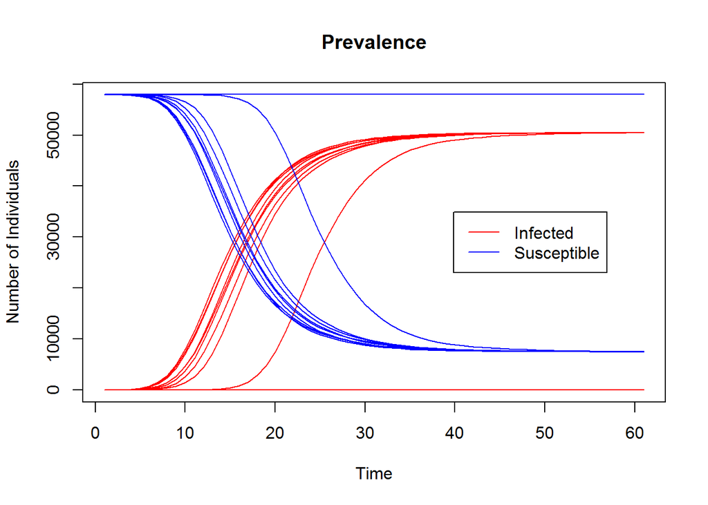

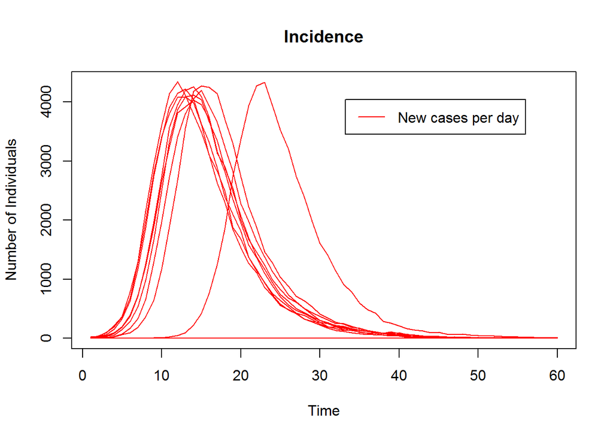

#### 2.3.1.1 What is the percentage of infected vertices when the epidemic starts at the vertex with the highest out-degree?

In the epidemic context, a **super-spreader** is a vertex (human, animal, computer etc.) that is alone responsible for a very high number of new infections. In the following, this will be shown exemplarily for the Gnutella network.

```r
# First the vertex with the highest outdegree needs to be found
maxdeg <- which(degree(n, mode = "out")==max(degree(n, mode = "out")))
max <- max(degree(n, mode = "out"))
print(paste("The vertex with the highest out-degree, is vertex number", maxdeg, "with an out-degree of", max,"."))
```

```
## [1] "The vertex with the highest out-degree, is vertex number 8950 with an out-degree of 78 ."
```

```r
# Because the epidemic starts now only at one vertex, init_inf must be set to 1
init_inf = 1

# In this case the epidemic will spread faster and it is sufficient to view 50 timesteps
simlength <- 50

# A new list infdata_end is created in order to save final number of infected vertices after each simulation
# round
infdata_end = list()

for (j in 1:simnumber){
infected <- logical(N)

# patientzero is now set to be the vertex with the highest out-degree
patientzero <- maxdeg

infected[patientzero] <- TRUE
susceptible = N - sum(infected)
infdata = list(sum(infected))
susdata = list(susceptible)
incidence = list()


for (i in 1:simlength) {
  discordant.links <- which(infected[links[,1]])
  transmit <- rbinom(length(discordant.links),1,beta)
  transmitter.links <- discordant.links[transmit==1]
  nodes.of.transmitter.links <- unique(as.vector(links[transmitter.links,1:2]))
  infected[nodes.of.transmitter.links] <- TRUE
  infdata[[i+1]]= sum(infected)
  susdata[[i+1]]= N - sum(infected)
  incidence[[i]]=susdata[[i]] - susdata[[i+1]]
}
  infdata_sum[[j]] = infdata
  susdata_sum[[j]] = susdata
  incidence_sum[[j]] = incidence

  # At the end of each simualation round, the final number of infected vertices is saved to infdata_end
  infdata_end[[j]] = sum(infected)
}

# Then the sum of all final resuls is calculated
sum <- Reduce("+", infdata_end)
# The the sum is devided by the number of simulation rounds to receive the average
avg <- sum/simnumber
# The average divided by the total number of vertices times 100 gives the percentage
percent <- (avg/N)*100
# Percent is formatted to show exactly two decimals
percent <- format(round(percent,2))

print(paste("On average,",percent,"% of all vertices in the network are infected after",simlength,"timesteps, if the epidemic starts to spread at vertex",maxdeg))
```

```
## [1] "On average, 87.01 % of all vertices in the network are infected after 50 timesteps, if the epidemic starts to spread at vertex 8950"
```

## 2.4 Gowalla

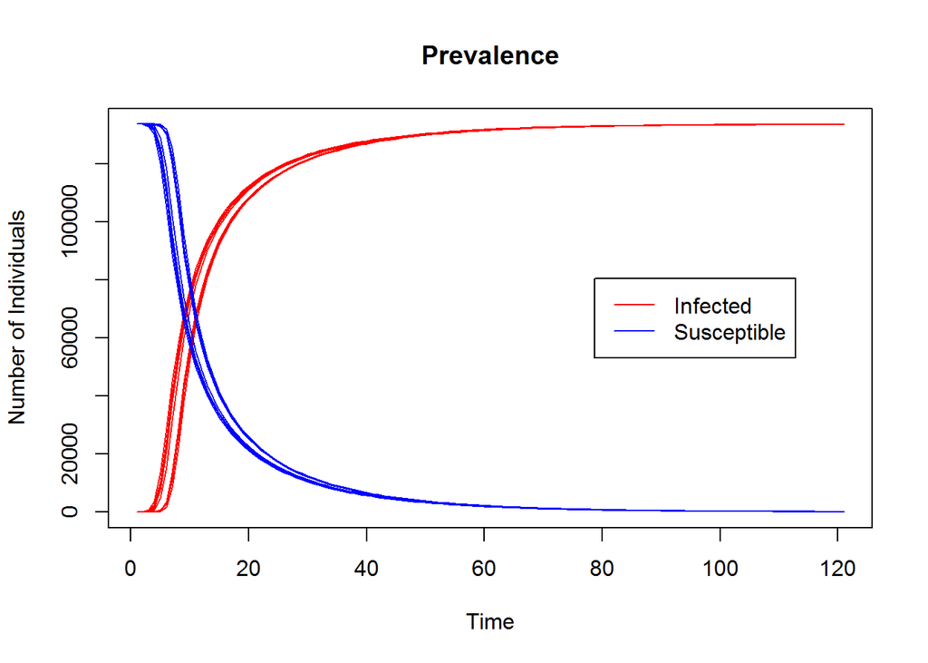

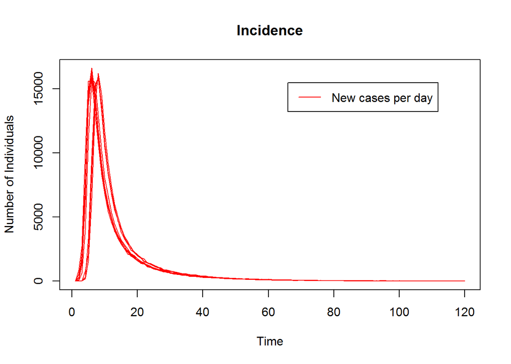